# Computer Assignment 4

# Machine Learning

## Ali Bahari

Project Name: Computer Assignment 4 Machine Learning

Project Goal: Use different machine learning algorithms to predict price of cars in a provided dataset in .csv format.

In this assignment a dataset of different cars is provided which includes different features for each car. Our goal is to use different machine learning algorithms to train our model and predict price of different cars based on our model. First of all we'll start with preprocessing the data and extract some additional features from it then we'll find the most informative features and use them in our advantage. So after preprocessing and choosing our features we'll divide the preprocessed dataset into two parts train and test set which will be used for training and evaluating our model respectively. After dividing the dataset we'll use linear regression, KNN , decision tree and random forest algorithms for training our data and finally we'll evaluate our results on our testset by MSE and RMSE.

```python
import pandas as pd
from hazm import *
import time
import numpy as np
from sklearn.feature_selection import mutual_info_regression
from sklearn.preprocessing import StandardScaler , LabelEncoder
import matplotlib.pyplot as plt
from IPython.core.display import HTML
```

```python
dataFrame = pd.read_csv("vehicles.csv")
dataFrame
```

|  | brand | category | created_at | description | image_count | mileage | price | title | year |
| --- | --- | --- | --- | --- | --- | --- | --- | --- | --- |
| 0 | NaN | heavy | Tuesday 07PM | سریال 43j$NUMبدون شکستگی سه حلقه لاستیک نو یک ... | 4 | NaN | -1 | لودر کاتر پیلار 950 | NaN |
| 1 | سایر | light | Wednesday 04AM | دوگانه ال پی جی بیمه با تخفیف دارد \nتودوزی نو... | 3 | 180000.0 | -1 | پاترول شش سیلندر چهار درب | 1366 |
| 2 | پژو ۴۰۵::Peugeot 405 | light | Wednesday 11AM | پژو 2000فنی تازه تعمیر بدنه بدون خطو خش تخیف ب... | 0 | 290000.0 | 8500000 | پژو مدل 81 مشکی | 1381 |
| 3 | نیسان::Nissan | light | Wednesday 01PM | سلام.\nماشین کاملا سالم همه چی فابریک متور زد ... | 3 | 175000.0 | 19500000 | پاترول 2در | 1372 |
| 4 | سمند::Samand | light | Thursday 07AM | سمند ال ایکس بدون رنگ تمامی سرویس ها انجام شده... | 4 | 80000.0 | 23900000 | سمند دوگانه کارخانه | 1391 |
| 5 | پژو ۴۰۵::Peugeot 405 | light | Thursday 08AM | بیمه یکسال ده سال تخفیف دور رنگ شاسی پلمپ سالم | 3 | 125000.0 | 8500000 | پژو405 مدل84 | 1384 |
| 6 | ام‌وی‌ام::MVM | light | Thursday 08AM | ام وی ام چهار سیلندر مدل 93 فنی سالم بدون رنگ ... | 2 | 11000.0 | 18500000 | ام وی ام 110 چهار سیلندر | 1393 |
| 7 | پراید صندوق‌دار::Pride | light | Thursday 09AM | یک پراید مدل 87خونگی بدون رنگ سفید هفت سال تخف... | 1 | 200000.0 | 11000000 | پرایدصبامدل87خونگی فابریک | 1387 |
| 8 | پراید هاچ‌بک::Pride | light | Friday 04AM | مدل 80 رنگ سفید بیمه تا برج ۱۱ فنی سالم رینگ ... | 3 | 1.0 | 7800000 | پراید هاچ بک مدل 80 | 1380 |
| 9 | سایر | light | Friday 12PM | در حد_ بسیار تمیز_ سرویس گارانتی انجام شده_ ما... | 1 | 17000.0 | 45000000 | جک جی ۵ دنده ای | 1393 |
| 10 | NaN | heavy | Friday 06PM | مدل ۸۲برج۱۲بدون رنگ بیمه بدنه وثالث ۱۳سال تخفی... | 4 | NaN | 222000000 | اف ام جفت باری | NaN |
| 11 | پژو پارس::Peugeot Pars | light | Saturday 06AM | پژو پارس سفید ،بدون رنگ ،ازنظر فنی کاملا سالم،... | 2 | 108000.0 | -1 | پژو پارس سفید 88بدون رنگ | 1388 |
| 12 | پراید صندوق‌دار::Pride | light | Saturday 12PM | پرایددوگانه فابریک سفیدفنی درجه یک تازه تعمیرب... | 3 | 250000.0 | 11000000 | پراید دوگانه فابربک | 1388 |
| 13 | پژو ۲۰۶‍::Peugeot 206 | light | Saturday 01PM | سقف و دوتا در فابریک ،شاسی راننده کمی خوردگی ،... | 4 | 120000.0 | 14800000 | 206تیپ دو | 1386 |
| 14 | پراید صندوق‌دار::Pride | light | Saturday 01PM | موتوری سالم-بیمه ومعاینه فنی تا پایان95- لاستی... | 4 | 250000.0 | 8000000 | پراید سفید مدل83 | 1383 |
| 15 | NaN | heavy | Saturday 08PM | بیل مکانیکی لیبهر 912\nموتور 6 سیلندر فنی سالم... | 2 | NaN | 65000000 | بیل مکانیکی لیبهر 912 | NaN |
| 16 | پژو ۴۰۵::Peugeot 405 | light | Sunday 08AM | از لحاظ متوری تمیز . بدون مشکل . کاپوت و گلگیر... | 2 | 160.0 | 21000000 | پژو ۴۰۵ TU5 بسیار تمیز | 1392 |
| 17 | پژو ۲۰۶‍::Peugeot 206 | light | Sunday 08AM | کم کار واقعی بدون کوچکترین ایراد یا خط و خش یا... | 1 | 48.0 | 24300000 | پژو۲۰۶ سفید مدل۹۳ | 1393 |
| 18 | پراید صندوق‌دار::Pride | light | Sunday 09AM | سلام پراید مدل 85 بدون رنگ بدون ضربه بدون موج ... | 2 | 135000.0 | 12000000 | پراید 85 بدون رنگ | 1385 |
| 19 | سمند::Samand | light | Sunday 11AM | فنی کاملاسالم،بیمه تابرج 2میباشدفقط1500قیمت ری... | 2 | 85000.0 | 25000000 | سمندال ایکس سفیدمدل 92 | 1392 |
| 20 | پراید هاچ‌بک::Pride | light | Sunday 02PM | لاستیک پهن٦٠درصد ١لکه رنگ سالم | 0 | 111.0 | 15500000 | پراید ١١١نوک مدادی | 1391 |
| 21 | پیکان::Peykan | light | Sunday 05PM | 13 سال تخفیف بیمه.معاینه.خوابیده سالم | 1 | 120000.0 | 5300000 | پیکان سواری81 | 1381 |
| 22 | پژو پارس::Peugeot Pars | light | Tuesday 07AM | بدون رنگ بیمه ۶ماه بدون خوردگی | 0 | 37000.0 | 34000000 | پارس ۹۴ داشبورد جدید | 1394 |
| 23 | وانت | light | Tuesday 08AM | گلگیر سمت راننده رنگ دارد متوری تمیز بدون ظربه | 0 | 20000.0 | -1 | پراید بار ١٥١ | 1393 |
| 24 | پژو پارس::Peugeot Pars | light | Tuesday 07PM | از لحاظ موتوری سالم | 0 | 121000.0 | 13000000 | بدون رنگ فابریک | 1382 |
| 25 | پژو روآ / آر‌دی::RD/ROA | light | Tuesday 07PM | باسلام.پژو روآ سالم.تازه تعمیر.لاستیک خوب.ظبط ... | 1 | 12345.0 | 9000000 | پژو روآ تر و تیمز | 1386 |
| 26 | سمند::Samand | light | Tuesday 08PM | ماشین تمیز بدون رنگ لوازم مصرفی تعویض شده لازم... | 0 | 86000.0 | 22000000 | سمند اس ای | 1391 |
| 27 | پژو ۲۰۶‍ صندوق‌دار::Peugeot 206 | light | Wednesday 11AM | بیمه تا برج 9- V8 سفارشی آپکو-سفید | 1 | 29000.0 | 33000000 | سفارشی ایرانخودرو | 1393 |
| 28 | سمند::Samand | light | Wednesday 02PM | ماشین خیلی سالمه کولرروشن.سیستم ...رینگ و لاست... | 3 | 1.0 | 11500 | سمندمدل٨١ | 1381 |
| 29 | پژو ۴۰۵::Peugeot 405 | light | Wednesday 04PM | پژو تمیز و خوش رخ کم کارکرد،بیمه تا خرداد ٩٦،ع... | 3 | 120000.0 | 18500000 | تمیز بدون خط و خش | 1389 |
| ... | ... | ... | ... | ... | ... | ... | ... | ... | ... |
| 130413 | پژو ۴۰۵::Peugeot 405 | light | Sunday 08AM | ماشین فوق العاده تمییز، یک کاپوت رنگ شدگی دارد... | 0 | 160000.0 | 17200000 | پژو جی ال ایکس تمییز | 1388 |
| 130414 | پژو پارس::Peugeot Pars | light | Monday 08AM | فروش خودرو فوری فوری بصورت نقد | 3 | 6000.0 | 39500000 | pars lx کلاس13 | 1395 |
| 130415 | سمند::Samand | light | Monday 08AM | از ابتدا تخفیف بیمه و چهارماه بیمه دارد.\nشمار... | 3 | 90000.0 | 21000000 | سمندLX دوگانه سوز کارخانه | 1390 |
| 130416 | سمند::Samand | light | Monday 10AM | با سلام . سمند ال ایکس سفید مدل برج ٨ سال ٨٩ .... | 3 | 150000.0 | 22000000 | سمند ال ایکس مدل ٨٩ | 1389 |
| 130417 | سمند::Samand | light | Monday 12PM | سمند مدل 92 موتوری به شرط \nبدون رنگ .خط و خش ... | 3 | 100000.0 | -1 | فروش سمند LX. ef7 | 1392 |
| 130418 | پراید صندوق‌دار::Pride | light | Monday 07PM | پراید۱۳۱سفیدرنگ، فابریک، ۲ایربک، ترمز abs ،فرم... | 0 | 56000.0 | 16000000 | پراید۹۲سفیدرنگ تمام فول | 1392 |
| 130419 | سمند::Samand | light | Tuesday 09AM | سمند دوگانه کارخانه، دارای گارانتی و بیمه تا م... | 3 | 28.0 | 29500000 | سمند دوگانه ال ایکس ای اف سون | 1394 |
| 130420 | NaN | heavy | Tuesday 06PM | کارت سند جرثقیل، یک سال بیمه، 10سال تخفیف، مدل... | 4 | NaN | -1 | جرثقیل بنز خاور608 | NaN |
| 130421 | سمند::Samand | light | Wednesday 08PM | دور رنگ از لحاظ موتوری سالم، بیمه تا آخر 95، چ... | 0 | 200000.0 | 13500000 | سمند دوگانه کارخانه رنگ دلفینی | 1386 |
| 130422 | سایر | light | Thursday 06AM | بیمه یکسال جلوبندی سالم کمکها اسپرت. شاسی پلمب... | 2 | 200.0 | 7900000 | نیو85 | 1385 |
| 130423 | تندر ۹۰::Tondar 90 | light | Thursday 01PM | سه لکه جزیی رنگ \nتخفیف بیمه دارد \nفنی و سوار... | 3 | 86000.0 | 25500000 | ال نود ۱۳۸۸ پارس خودرو | 1388 |
| 130424 | سایر | light | Thursday 09PM | بیمه تا برج3 سال دیکه داره بین در گلگیر اندازه... | 4 | 88000.0 | 66000000 | MG$NUM | 1392 |
| 130425 | پراید صندوق‌دار::Pride | light | Friday 09AM | ۱سال بیمه،۵سال تخفیف بیمه، لاستیک۵۰٪،دوررنگ سق... | 4 | 370.0 | 6000000 | پراید یشمی متالیک | 1381 |
| 130426 | پژو ۲۰۶‍::Peugeot 206 | light | Friday 10AM | 206 ، مدل 1384 ، تیپ 3 ، بیمه تا برج 4 سال 96 ... | 2 | 218000.0 | 16900000 | 206 تیپ 3 مدل 84 | 1384 |
| 130427 | سمند::Samand | light | Friday 10AM | سمندef7 مدل ۹۰ کم کارکرد ، سفید ، فنی سالم ، ب... | 0 | 40000.0 | 23000000 | سمندEF7 مدل ۹۰ | 1390 |
| 130428 | سایر | light | Friday 11AM | به علت از خط و خش دست پایین رنگ است.تصادف ی هی... | 4 | 230000.0 | 83000000 | ون فولوکسT5 فول | 1386 |
| 130429 | هیوندای سوناتا::Hyundai Sonata | light | Friday 12PM | وارداتی.تومشکی.بیمه فول.تخفیف بیمه فول.لاستیک ... | 3 | 85000.0 | 79000000 | هیوندا.سوناتا 2009سفید | 1388 |
| 130430 | نیسان::Nissan | light | Saturday 08AM | ماشین مدل ۱۳۹۴/١۰/٢۰\nدارای باربند کفی سیستم ب... | 1 | 13000.0 | 32000000 | نیسان زامیاد درحدصفردوگانه | 1394 |
| 130431 | تندر ۹۰::Tondar 90 | light | Saturday 10AM | خودروی کارمندی .بدون کوچکترین ضربه ورنگ.یک میل... | 1 | 10500.0 | 40000000 | پارس تندر L90.E2 | 1395 |
| 130432 | پراید صندوق‌دار::Pride | light | Sunday 06PM | بازدید= خرید | 2 | 340000.0 | 6900000 | پراید 76 کره ای | 1376 |
| 130433 | پژو ۴۰۵::Peugeot 405 | light | Monday 01PM | پژو GLX تاکسی گردشی مدل ۱۳۹۰ بسیار کم کارکرد\... | 1 | 120000.0 | 25900000 | پژو 405 GLX تاکسی گردشی | 1390 |
| 130434 | وانت | light | Monday 04PM | ماشین سالم . یک گلگیر رنگ . بیمه تا برج ۷ سال ... | 3 | 199000.0 | -1 | وانت پیکان مدل ۸۴ | 1384 |
| 130435 | تندر ۹۰::Tondar 90 | light | Tuesday 02PM | فوق‌العاده سالم بدون رنگ دزدگیر ماجیکار شیشه ه... | 2 | 173000.0 | 30000000 | ال۹۰ E2 | 1390 |
| 130436 | پراید صندوق‌دار::Pride | light | Tuesday 05PM | مدل 84 تمیز. بدون رنگ. سیستم صوتی. رینگ و لاست... | 3 | 140000.0 | 11000000 | پراید مدل 84 بدون رنگ | 1384 |
| 130437 | پژو ۴۰۵::Peugeot 405 | light | Wednesday 08AM | ۴۰۵slxیا همان tufصفر کیلومتر سند خورده تحویل د... | 3 | 1.0 | -1 | ۴۰۵slx | 1395 |
| 130438 | NaN | heavy | Wednesday 03PM | بادسان فوق بیرنگ سفید رنگ بیمه تابرج 3.96 تخفی... | 2 | NaN | 48000000 | بادسان 8b14 مدل83 | NaN |
| 130439 | NaN | heavy | Wednesday 06PM | باسلام .تراکتورازصفری دست خودم بوده.سالم.ودارا... | 4 | NaN | -1 | تراکتورگلدونی ۲۳۸ایتالیا | NaN |
| 130440 | سمند::Samand | light | Wednesday 06PM | ماشینم تصادفیه با خریدار توافق میکنم سر قیمتش | 3 | 20000.0 | -1 | خودرو سمند تصادفی مدل92 | 1392 |
| 130441 | پراید صندوق‌دار::Pride | light | Thursday 03PM | سند۲ برگ،بیمه تا برج$NUMتخفیفات بیمه 15 سال،مع... | 4 | 123000.0 | 6900000 | پراید 79 بسیار سالم | 1379 |
| 130442 | پراید صندوق‌دار::Pride | light | Friday 04PM | پراید دوگانه کارخانه میباشد و کم کارکرد.روکش .... | 3 | 43000.0 | 17400000 | پراید دوگانه کارخانه مدل93 | 1393 |

130443 rows × 9 columns

```python
print("Number of records: " + str(len(dataFrame)))
```

```
Number of records: 130443
```

#### Some info + Question 4

First of all we have to make some changes in the dataset. Upon checking the dataset, you can see that some prices have -1 value which means the price for that record is missing. Also some records have NaN values for some features which means the value for that feature is missing. There are multiple ways to approach these records. We can simply drop them since we don't have info about them, although this method can be implemented without any problem, sometimes it'll perform badly and also it'll result in smaller dataset if the missing values are a lot which is always an undesired phenomena. Another way of approaching missing values is using mean or median of all the values for that feature instead of the missing value. This method is good for small dataset and surely saves us from losing data which really important but it won't perform well in large datasets and also it can only be used for numerical values. Another way of approaching missing values is using the most frequent value of that feature instead of missing value or simply putting a new unique value for missing data. This method will solve the problem of the last method since it can be used for categorical data but it can't be used for numerical values and also addition of new features to the model while encoding may result in poor performance.

For this project I've used all the methods above since we have NaN values both in categorical(brand) and numerical(mileage and year) form. By experimenting I came to the conclusion that removing missing data will result in lower RMSE so I used this method. For price feature since it'll be our result there's no other way than removing them so whatever method you use you have to remove prices that have -1 value. Also since mileage can be any value it made more sense to me to use mean for it but for year since it must be a natural number it made more sense to me to use median for it.

Also there were some values in year equal to <1366 which I replaced them with 1365 to have a numerical value instead.

```python
dataFrame.isnull().sum()
```

```
brand          9992
category          0
created_at        0
description       0
image_count       0
mileage        9992
price             0
title             0
year           9992
dtype: int64
```

```python
dataFrame = dataFrame[dataFrame["price"] != -1]
dataFrame = dataFrame.dropna()
dataFrame["year"] = dataFrame["year"].replace(["<1366"] , 1365)

# dataFrame["brand"] = dataFrame["brand"].fillna("نامشخص")
# dataFrame["mileage"] = dataFrame["mileage"].fillna(dataFrame["mileage"].mean())
# dataFrame["year"] = dataFrame["year"].fillna(dataFrame["year"].median())

dataFrame
```

|  | brand | category | created_at | description | image_count | mileage | price | title | year |
| --- | --- | --- | --- | --- | --- | --- | --- | --- | --- |
| 2 | پژو ۴۰۵::Peugeot 405 | light | Wednesday 11AM | پژو 2000فنی تازه تعمیر بدنه بدون خطو خش تخیف ب... | 0 | 290000.0 | 8500000 | پژو مدل 81 مشکی | 1381 |
| 3 | نیسان::Nissan | light | Wednesday 01PM | سلام.\nماشین کاملا سالم همه چی فابریک متور زد ... | 3 | 175000.0 | 19500000 | پاترول 2در | 1372 |
| 4 | سمند::Samand | light | Thursday 07AM | سمند ال ایکس بدون رنگ تمامی سرویس ها انجام شده... | 4 | 80000.0 | 23900000 | سمند دوگانه کارخانه | 1391 |
| 5 | پژو ۴۰۵::Peugeot 405 | light | Thursday 08AM | بیمه یکسال ده سال تخفیف دور رنگ شاسی پلمپ سالم | 3 | 125000.0 | 8500000 | پژو405 مدل84 | 1384 |
| 6 | ام‌وی‌ام::MVM | light | Thursday 08AM | ام وی ام چهار سیلندر مدل 93 فنی سالم بدون رنگ ... | 2 | 11000.0 | 18500000 | ام وی ام 110 چهار سیلندر | 1393 |
| 7 | پراید صندوق‌دار::Pride | light | Thursday 09AM | یک پراید مدل 87خونگی بدون رنگ سفید هفت سال تخف... | 1 | 200000.0 | 11000000 | پرایدصبامدل87خونگی فابریک | 1387 |
| 8 | پراید هاچ‌بک::Pride | light | Friday 04AM | مدل 80 رنگ سفید بیمه تا برج ۱۱ فنی سالم رینگ ... | 3 | 1.0 | 7800000 | پراید هاچ بک مدل 80 | 1380 |
| 9 | سایر | light | Friday 12PM | در حد_ بسیار تمیز_ سرویس گارانتی انجام شده_ ما... | 1 | 17000.0 | 45000000 | جک جی ۵ دنده ای | 1393 |
| 12 | پراید صندوق‌دار::Pride | light | Saturday 12PM | پرایددوگانه فابریک سفیدفنی درجه یک تازه تعمیرب... | 3 | 250000.0 | 11000000 | پراید دوگانه فابربک | 1388 |
| 13 | پژو ۲۰۶‍::Peugeot 206 | light | Saturday 01PM | سقف و دوتا در فابریک ،شاسی راننده کمی خوردگی ،... | 4 | 120000.0 | 14800000 | 206تیپ دو | 1386 |
| 14 | پراید صندوق‌دار::Pride | light | Saturday 01PM | موتوری سالم-بیمه ومعاینه فنی تا پایان95- لاستی... | 4 | 250000.0 | 8000000 | پراید سفید مدل83 | 1383 |
| 16 | پژو ۴۰۵::Peugeot 405 | light | Sunday 08AM | از لحاظ متوری تمیز . بدون مشکل . کاپوت و گلگیر... | 2 | 160.0 | 21000000 | پژو ۴۰۵ TU5 بسیار تمیز | 1392 |
| 17 | پژو ۲۰۶‍::Peugeot 206 | light | Sunday 08AM | کم کار واقعی بدون کوچکترین ایراد یا خط و خش یا... | 1 | 48.0 | 24300000 | پژو۲۰۶ سفید مدل۹۳ | 1393 |
| 18 | پراید صندوق‌دار::Pride | light | Sunday 09AM | سلام پراید مدل 85 بدون رنگ بدون ضربه بدون موج ... | 2 | 135000.0 | 12000000 | پراید 85 بدون رنگ | 1385 |
| 19 | سمند::Samand | light | Sunday 11AM | فنی کاملاسالم،بیمه تابرج 2میباشدفقط1500قیمت ری... | 2 | 85000.0 | 25000000 | سمندال ایکس سفیدمدل 92 | 1392 |
| 20 | پراید هاچ‌بک::Pride | light | Sunday 02PM | لاستیک پهن٦٠درصد ١لکه رنگ سالم | 0 | 111.0 | 15500000 | پراید ١١١نوک مدادی | 1391 |
| 21 | پیکان::Peykan | light | Sunday 05PM | 13 سال تخفیف بیمه.معاینه.خوابیده سالم | 1 | 120000.0 | 5300000 | پیکان سواری81 | 1381 |
| 22 | پژو پارس::Peugeot Pars | light | Tuesday 07AM | بدون رنگ بیمه ۶ماه بدون خوردگی | 0 | 37000.0 | 34000000 | پارس ۹۴ داشبورد جدید | 1394 |
| 24 | پژو پارس::Peugeot Pars | light | Tuesday 07PM | از لحاظ موتوری سالم | 0 | 121000.0 | 13000000 | بدون رنگ فابریک | 1382 |
| 25 | پژو روآ / آر‌دی::RD/ROA | light | Tuesday 07PM | باسلام.پژو روآ سالم.تازه تعمیر.لاستیک خوب.ظبط ... | 1 | 12345.0 | 9000000 | پژو روآ تر و تیمز | 1386 |
| 26 | سمند::Samand | light | Tuesday 08PM | ماشین تمیز بدون رنگ لوازم مصرفی تعویض شده لازم... | 0 | 86000.0 | 22000000 | سمند اس ای | 1391 |
| 27 | پژو ۲۰۶‍ صندوق‌دار::Peugeot 206 | light | Wednesday 11AM | بیمه تا برج 9- V8 سفارشی آپکو-سفید | 1 | 29000.0 | 33000000 | سفارشی ایرانخودرو | 1393 |
| 28 | سمند::Samand | light | Wednesday 02PM | ماشین خیلی سالمه کولرروشن.سیستم ...رینگ و لاست... | 3 | 1.0 | 11500 | سمندمدل٨١ | 1381 |
| 29 | پژو ۴۰۵::Peugeot 405 | light | Wednesday 04PM | پژو تمیز و خوش رخ کم کارکرد،بیمه تا خرداد ٩٦،ع... | 3 | 120000.0 | 18500000 | تمیز بدون خط و خش | 1389 |
| 30 | سایر | light | Wednesday 06PM | پیکان بار مدل 87 دوگانه سوز .بیمه نداره .برای ... | 1 | 115000.0 | 8000000 | پیکان بار مدل 87 | 1387 |
| 31 | تیبا::Tiba | light | Thursday 08AM | تیبا آبی کاربنی،بسیار تمیز و سالم،تمامی سرویس ... | 4 | 41000.0 | 20500000 | تیبا 93 | 1393 |
| 32 | پژو ۲۰۶‍::Peugeot 206 | light | Thursday 08AM | بیمه تا اول دی بیرنگ | 0 | 168000.0 | 14500000 | ۲۰۶ تیپ ۲ مدل ۸۴ | 1384 |
| 33 | پراید صندوق‌دار::Pride | light | Thursday 10AM | مدل 87 دو گانه -هشت سال تخفیف بیمه سه تیکه رنگ... | 1 | 265000.0 | 10500000 | پراید | 1387 |
| 34 | وانت | light | Thursday 12PM | در حد . قیمت مقطوع | 0 | 67000.0 | 13800000 | وانت پیکان 92/12 بدون رنگ | 1392 |
| 35 | سمند::Samand | light | Friday 10AM | سمند ال ایکس بی رنگ .سفید.رینگ اسپرت .بیمه تا ... | 2 | 100000.0 | 24000000 | سمند ال ایکس مالتی پلکس | 1392 |
| ... | ... | ... | ... | ... | ... | ... | ... | ... | ... |
| 130406 | پراید صندوق‌دار::Pride | light | Friday 06PM | پراید سفید مدل 91/12 بفروش میرسد.دو گلگیر جلو ... | 0 | 2.0 | 13700000 | پراید سفید مدل91 | 1391 |
| 130407 | سمند::Samand | light | Saturday 12AM | باسلام \nخودرو فوق بدون کوچکترین رنگ شدگی میبا... | 3 | 60000.0 | 26400000 | سمندef7مدل92دوگانه کارخانه | 1392 |
| 130408 | پراید صندوق‌دار::Pride | light | Saturday 07AM | هشت سال تخفیف بیمه ۱۱ماه بیمه چهار حلقه لاستیک... | 2 | 250000.0 | 5700000 | پراید یشمی ۸۰سالم | 1380 |
| 130409 | پراید صندوق‌دار::Pride | light | Saturday 11AM | با سلام ماشین بدون خط و خش بیمه 16/2/96کم کارک... | 4 | 60000.0 | 15000000 | پراید132sl | 1390 |
| 130410 | پژو پارس::Peugeot Pars | light | Saturday 12PM | پژو پارس دوگانه کاپوت جلو و صندوق عقب از رو رن... | 4 | 200000.0 | 19000000 | پژو پارس | 1386 |
| 130411 | پراید صندوق‌دار::Pride | light | Saturday 05PM | پراید استثنائی بدون رنگ.بیمه تا4سال دیگه.تخفیف... | 2 | 220000.0 | 9800000 | پراید 83نقره ای بدون رنگ | 1383 |
| 130412 | سمند::Samand | light | Sunday 05AM | سمند LX مشکی مدل 86 دوگانه دستی بیمه بدنه وشخص... | 3 | 300.0 | 15400000 | سمند LX دوگانه | 1386 |
| 130413 | پژو ۴۰۵::Peugeot 405 | light | Sunday 08AM | ماشین فوق العاده تمییز، یک کاپوت رنگ شدگی دارد... | 0 | 160000.0 | 17200000 | پژو جی ال ایکس تمییز | 1388 |
| 130414 | پژو پارس::Peugeot Pars | light | Monday 08AM | فروش خودرو فوری فوری بصورت نقد | 3 | 6000.0 | 39500000 | pars lx کلاس13 | 1395 |
| 130415 | سمند::Samand | light | Monday 08AM | از ابتدا تخفیف بیمه و چهارماه بیمه دارد.\nشمار... | 3 | 90000.0 | 21000000 | سمندLX دوگانه سوز کارخانه | 1390 |
| 130416 | سمند::Samand | light | Monday 10AM | با سلام . سمند ال ایکس سفید مدل برج ٨ سال ٨٩ .... | 3 | 150000.0 | 22000000 | سمند ال ایکس مدل ٨٩ | 1389 |
| 130418 | پراید صندوق‌دار::Pride | light | Monday 07PM | پراید۱۳۱سفیدرنگ، فابریک، ۲ایربک، ترمز abs ،فرم... | 0 | 56000.0 | 16000000 | پراید۹۲سفیدرنگ تمام فول | 1392 |
| 130419 | سمند::Samand | light | Tuesday 09AM | سمند دوگانه کارخانه، دارای گارانتی و بیمه تا م... | 3 | 28.0 | 29500000 | سمند دوگانه ال ایکس ای اف سون | 1394 |
| 130421 | سمند::Samand | light | Wednesday 08PM | دور رنگ از لحاظ موتوری سالم، بیمه تا آخر 95، چ... | 0 | 200000.0 | 13500000 | سمند دوگانه کارخانه رنگ دلفینی | 1386 |
| 130422 | سایر | light | Thursday 06AM | بیمه یکسال جلوبندی سالم کمکها اسپرت. شاسی پلمب... | 2 | 200.0 | 7900000 | نیو85 | 1385 |
| 130423 | تندر ۹۰::Tondar 90 | light | Thursday 01PM | سه لکه جزیی رنگ \nتخفیف بیمه دارد \nفنی و سوار... | 3 | 86000.0 | 25500000 | ال نود ۱۳۸۸ پارس خودرو | 1388 |
| 130424 | سایر | light | Thursday 09PM | بیمه تا برج3 سال دیکه داره بین در گلگیر اندازه... | 4 | 88000.0 | 66000000 | MG$NUM | 1392 |
| 130425 | پراید صندوق‌دار::Pride | light | Friday 09AM | ۱سال بیمه،۵سال تخفیف بیمه، لاستیک۵۰٪،دوررنگ سق... | 4 | 370.0 | 6000000 | پراید یشمی متالیک | 1381 |
| 130426 | پژو ۲۰۶‍::Peugeot 206 | light | Friday 10AM | 206 ، مدل 1384 ، تیپ 3 ، بیمه تا برج 4 سال 96 ... | 2 | 218000.0 | 16900000 | 206 تیپ 3 مدل 84 | 1384 |
| 130427 | سمند::Samand | light | Friday 10AM | سمندef7 مدل ۹۰ کم کارکرد ، سفید ، فنی سالم ، ب... | 0 | 40000.0 | 23000000 | سمندEF7 مدل ۹۰ | 1390 |
| 130428 | سایر | light | Friday 11AM | به علت از خط و خش دست پایین رنگ است.تصادف ی هی... | 4 | 230000.0 | 83000000 | ون فولوکسT5 فول | 1386 |
| 130429 | هیوندای سوناتا::Hyundai Sonata | light | Friday 12PM | وارداتی.تومشکی.بیمه فول.تخفیف بیمه فول.لاستیک ... | 3 | 85000.0 | 79000000 | هیوندا.سوناتا 2009سفید | 1388 |
| 130430 | نیسان::Nissan | light | Saturday 08AM | ماشین مدل ۱۳۹۴/١۰/٢۰\nدارای باربند کفی سیستم ب... | 1 | 13000.0 | 32000000 | نیسان زامیاد درحدصفردوگانه | 1394 |
| 130431 | تندر ۹۰::Tondar 90 | light | Saturday 10AM | خودروی کارمندی .بدون کوچکترین ضربه ورنگ.یک میل... | 1 | 10500.0 | 40000000 | پارس تندر L90.E2 | 1395 |
| 130432 | پراید صندوق‌دار::Pride | light | Sunday 06PM | بازدید= خرید | 2 | 340000.0 | 6900000 | پراید 76 کره ای | 1376 |
| 130433 | پژو ۴۰۵::Peugeot 405 | light | Monday 01PM | پژو GLX تاکسی گردشی مدل ۱۳۹۰ بسیار کم کارکرد\... | 1 | 120000.0 | 25900000 | پژو 405 GLX تاکسی گردشی | 1390 |
| 130435 | تندر ۹۰::Tondar 90 | light | Tuesday 02PM | فوق‌العاده سالم بدون رنگ دزدگیر ماجیکار شیشه ه... | 2 | 173000.0 | 30000000 | ال۹۰ E2 | 1390 |
| 130436 | پراید صندوق‌دار::Pride | light | Tuesday 05PM | مدل 84 تمیز. بدون رنگ. سیستم صوتی. رینگ و لاست... | 3 | 140000.0 | 11000000 | پراید مدل 84 بدون رنگ | 1384 |
| 130441 | پراید صندوق‌دار::Pride | light | Thursday 03PM | سند۲ برگ،بیمه تا برج$NUMتخفیفات بیمه 15 سال،مع... | 4 | 123000.0 | 6900000 | پراید 79 بسیار سالم | 1379 |
| 130442 | پراید صندوق‌دار::Pride | light | Friday 04PM | پراید دوگانه کارخانه میباشد و کم کارکرد.روکش .... | 3 | 43000.0 | 17400000 | پراید دوگانه کارخانه مدل93 | 1393 |

103799 rows × 9 columns

```python
print("Number of columns: " + str(len(dataFrame.columns)))
print("Number of rows: " + str(len(dataFrame)))
print("==========")
print(dataFrame["brand"].describe())
print("==========")
print(dataFrame["category"].describe())
print("==========")
print("Number of records: " + str(len(dataFrame)))
print("==========")
print(dataFrame.info())
print("==========")
print(dataFrame.describe())
```

```
Number of columns: 9
Number of rows: 103799
==========
count                     103799
unique                        26
top       پراید صندوق‌دار::Pride
freq                       25236
Name: brand, dtype: object
==========
count     103799
unique         1
top        light
freq      103799
Name: category, dtype: object
==========
Number of records: 103799
==========
<class 'pandas.core.frame.DataFrame'>
Int64Index: 103799 entries, 2 to 130442
Data columns (total 9 columns):
brand          103799 non-null object
category       103799 non-null object
created_at     103799 non-null object
description    103799 non-null object
image_count    103799 non-null int64
mileage        103799 non-null float64
price          103799 non-null int64
title          103799 non-null object
year           103799 non-null object
dtypes: float64(1), int64(2), object(6)
memory usage: 7.9+ MB
None
==========
         image_count        mileage         price
count  103799.000000  103799.000000  1.037990e+05
mean        1.872532  102948.701683  2.334332e+07
std         1.475499   97950.644880  2.637852e+07
min         0.000000       0.000000  1.000000e+00
25%         0.000000   21000.000000  1.090000e+07
50%         2.000000   80000.000000  1.660000e+07
75%         3.000000  160000.000000  2.600000e+07
max        14.000000  500000.000000  4.000000e+08
```

#### Some info + Question 2

In machine learning we want numerical values but most of the time there will be categorical values in our dataset. We can convert these values to numerical values. Like here in our dataset brand and category are categorical data. We can deal with categorical values in two different ways. The first one is using label encoding, which assigns one number to each category. The second one is using one-hot encoding, which will assign different columns to each category. Before we start transforming our data, it is important to figure out if the feature we are working on is ordinal or nominal. An ordinal feature is best described as a feature with natural, ordered categories and the distances between the categories is unknown. We can use LabelEncoder for ordinal features not nominal features. In nominal features we can’t replace the categories by a number since this would imply the features have an order, which is wrong for brand and category in our dataset. So we should use a nominal encoding. The most popular way to encode nominal features is one-hot-encoding. Essentially, each categorical feature with n categories is transformed into n binary features. If the number of the categorical features is low (relative to the amount of data) one-hot encoding will work best. But if the number of the categorical features is large and the dataset is small, one-hot encoding may not be feasible, and regressor may not be able to efficiently learn.

I have tested both of the methods and to be honest both of them had quite the same accuracy at the end but according to the reason stated above for using one hot encoding and since we have 26 brands and our data is large enough I prefered to use one hot encoding. And also since one hot encoding values are 0 or 1 it can't get biased like in label encoding if the number of unique values are a lot, one hot is kinda normalized and the range of its values is much less.

```python
# One Hot Encoding
brandOneHot = pd.get_dummies(dataFrame["brand"])
categoryOneHot = pd.get_dummies(dataFrame["category"])

# Label encoding for created_at used in gain bar chart
labelEncoder = LabelEncoder()
created_atLabelEncode = labelEncoder.fit_transform(dataFrame["created_at"].astype(str))
created_atLabelEncode = created_atLabelEncode.reshape(-1 , 1)
```

#### Some info + Question 1:

As we learned in the course lectures, the features to use in our model for learning are the ones that are more informative and also we learned that we can find how much informative and valuable a feature is by calculating information gain of that feature. In sklearn library the method mutual_info_regression can be used to calculate gain. Regression Mutual Infomation is similar to the Information Gain, but it's for continuous problems.

So let's take a look at our features before calculating gain of them. First of all by removing NaN values all the records with heavy category value will be removed so this means that category will only have one value, light. So this won't give us any useful info and as it's shown below in the bar chart the gain for that feature is zero. Second of all created_at and image_count features certainly won't have any useful info since they don't have any useful info for determining the price. But for being completely sure I calculated the gain for them. I used label encoding for created_at to get the results faster since calculating gain below takes some time for brand that is one hot encoded. Other gains are calculated below as well.

So in general if information gain (the values in the bar chart below) is high it means that the corresponding feature can provide more information than the others meaning that it'll help the training procedure more so it's a good idea to keep that feature in the dataset and use it's values in the training.

mutual_info_regression is used and the feature values and the target of dataset(price) is passed to it. random_state is explained further down the report. Everything else in the codes seems to be clear.

For brand and category I used one hot but for created_at since it had a lot of unique values I decided to use label encoder to reduce the number of columns. Reducing the number of columns for created_at was necessary since otherwise it'll take forever to get the information gain below if we have used one hot.(I know that since I have tried it and failed miserably:) )

```
informationGainFeatures calculated!
oneHotCategoryInfoGain calculated!
createdAtIG calculated!
oneHotBrandInfoGain calculated!
```

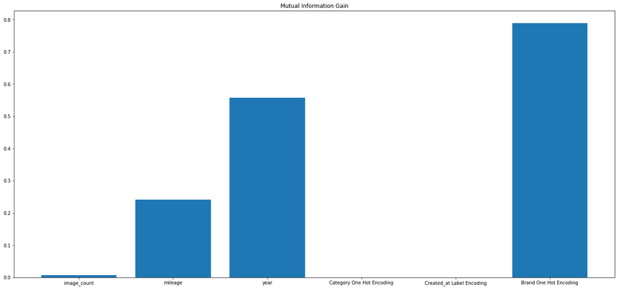

```python
features = ["image_count" , "mileage" , "year"]
X = dataFrame[features]
Y = dataFrame["price"]
informationGainFeatures = mutual_info_regression(X , Y , random_state = 42)
print("informationGainFeatures calculated!")
oneHotCategoryInfoGain = mutual_info_regression(categoryOneHot , Y , random_state = 42)
print("oneHotCategoryInfoGain calculated!")
createdAtIG = mutual_info_regression(created_atLabelEncode , Y , random_state = 42)
print("createdAtIG calculated!")
oneHotBrandInfoGain = mutual_info_regression(brandOneHot , Y , random_state = 42)
print("oneHotBrandInfoGain calculated!")

barFigure = plt.figure()
ax = barFigure.add_axes([0,0,3,2])
ax.bar(np.concatenate((features, ["Category One Hot Encoding" , "Created_at Label Encoding" , "Brand One Hot Encoding"])),
       np.concatenate((informationGainFeatures, [sum(oneHotCategoryInfoGain), sum(createdAtIG), sum(oneHotBrandInfoGain)])))
plt.title("Mutual Information Gain")
plt.show()
```

According to bar chart above only year and brand are valuable and informative so they'll be used. Mileage also can be used since it doesn't as much gain as brand and year but it's more than other. I evaluated the models both with and without mileage and including mileage as a feature had better results so I decided to keep it as a feature.

So image_count, created_at and category will be dropped and since we're using one hot for brand the brand column will be removed as well and replaced by 26 columns of one hot.

```python
# I also dropped mileage column for testing if it'll lower RMSE since it doesn't have that high of a gain.
# dataFrame = dataFrame.drop(columns = ["mileage"])

dataFrame = dataFrame.drop(columns = ["brand", "category" , "image_count" , "created_at"])
```

Now it's time to deal with description and title. It's similar to the last project first merge text and description and normalize them then remove punctuation and white space then get the words of the sentence and after removing stop words finally lemmatize them. The only difference here is that since we'll use tfidfVectorizer next we need the sentences so after lemmatizing the words will put them together to make a sentence.

```python
punctuation = set('''?\#$%@&^.؟؛][=*×،!-+ـ)(٪:«»<>…/_.,{};~'"|٬٫''')
whitespace = {"\t" , "\n" , "\r"}
stopWords = set(stopwords_list())

dataFrame["combinedTexts"] = dataFrame["description"] + " " + dataFrame["title"]
dataFrame = dataFrame.drop(columns = ["title", "description"])

def removePunctuationWhitespaceAndGetWords(text):
    i = 0
    while(i < len(text)):
        if(text[i] in whitespace or text[i] in punctuation):
            text = text[:i] + "" + text[i+1:]
            continue
        i += 1
    return word_tokenize(text)

def removeStopWordsAndLemmatizeWords(words):
    finalText = ""
    for word in words:
        if(word not in stopWords):
            lemmatizedWord = lemmatizer.lemmatize(word)
            finalText += (lemmatizedWord + " ")

    return finalText

lemmatizer = Lemmatizer()
normalizer = Normalizer()
dataFrame["combinedTexts"] = dataFrame["combinedTexts"].apply(normalizer.normalize)
dataFrame["combinedTexts"] = dataFrame["combinedTexts"].apply(removePunctuationWhitespaceAndGetWords)
dataFrame["combinedTexts"] = dataFrame["combinedTexts"].apply(removeStopWordsAndLemmatizeWords)
```

#### Some Info + Question 3

After implementing the procedure of tdidfVectorizer myself and the implementation taking too much time (near 10 minutes for each run) I decided to use tfidfVectorizer from sklearn which made everything much more easier. We'll give the vectorizer the sentences from last part and by choosing max_features and setting it to desired value like n we'll get tf-idf of top n words. I also used word names as column identifiers to know what each tf-idf refers to.

My implementation is commented here. It counts the number of word occurrence in each sentence and also records the number of sentences having a particular word it also records the number of occurrence of each word so that we can choose the top words as our features. tf-idf is calculated by it's formula which is:

tf(t,d) = count of word t in sentence d / number of words in sentence d

df(t) = occurrence of word t in documents (sentences)

idf(t) = log(N/(df + 1)) N: Total number of sentences

$tf-idf(t, d) = tf(t, d) * log(N/(df + 1))$

I have used different values for max_feature 50, 100, 150, 250, 500 and in all of them there wasn't a huge different in RMSE so by try and error I used the one that gave the best possible RMSE.

```python
# punctuation = set('''?\#$%@&^.؟؛][=*×،!-+ـ)(٪:«»<>…/_.,{};~'"|٬٫''')
# whitespace = {"\t" , "\n" , "\r"}
# stopWords = set(stopwords_list())

# dataFrame["combinedTexts"] = dataFrame["description"] + " " + dataFrame["title"]
# dataFrame = dataFrame.drop(columns = ["title", "description"])

# numWords = {}
# numWordsEachRow = []

# def removePunctuationWhitespaceAndGetWords(text):
#     i = 0
#     while(i < len(text)):
#         if(text[i] in whitespace or text[i] in punctuation):
#             text = text[:i] + "" + text[i+1:]
#             continue
#         i += 1
#     return word_tokenize(text)

# def removeStopWordsAndLemmatizeWords(words):
#     finalWords = set()
#     rowNums = {}
#     for word in words:
#         if(word not in stopWords):
#             lemmatizedWord = lemmatizer.lemmatize(word)
#             finalWords.add(lemmatizedWord)

#             if(lemmatizedWord not in numWords):
#                 numWords[lemmatizedWord] = 1
#             else:
#                 numWords[lemmatizedWord] += 1

#             if(lemmatizedWord not in rowNums):
#                 rowNums[lemmatizedWord] = 1
#             else:
#                 rowNums[lemmatizedWord] += 1

#     numWordsEachRow.append(rowNums)

#     return finalWords

# lemmatizer = Lemmatizer()
# normalizer = Normalizer()
# dataFrame["combinedTexts"] = dataFrame["combinedTexts"].apply(normalizer.normalize)
# dataFrame["combinedTexts"] = dataFrame["combinedTexts"].apply(removePunctuationWhitespaceAndGetWords)
# dataFrame["combinedTexts"] = dataFrame["combinedTexts"].apply(removeStopWordsAndLemmatizeWords)

# numWordsEachRow = numWordsEachRow[::-1]




# totalNumWordsEachRow = []
# totalNumOfOccuranceInDF = {}

# def fillNumWords(numWords , words):
#     for word in words:
#         if(word not in totalNumOfOccuranceInDF):
#             totalNumOfOccuranceInDF[word] = 1
#         else:
#             totalNumOfOccuranceInDF[word] += 1

#     totalNumWordsEachRow.append(len(words))


# dataFrame.apply(lambda row : fillNumWords(numWords , row["combinedTexts"]), axis = 1);
# newFeaturesList = sorted(numWords.items(), key = lambda item: item[1], reverse=True)[:250]

# totalNumWordsEachRow = totalNumWordsEachRow[::-1]
# indices = list(dataFrame.index)[::-1]




# def addFeaturesToDF(row , newFeaturesList , numWordsEachRow , totalNumWordsEachRow , totalNumOfOccuranceInDF , indices):
#     for word , _ in newFeaturesList:
#         if(word in numWordsEachRow[-1]):
#             dataFrame.loc[indices[-1] , word] = (numWordsEachRow[-1][word] / totalNumWordsEachRow[-1]) * \
#                                                 (np.log10(len(dataFrame) / totalNumOfOccuranceInDF[word]) )
#     numWordsEachRow.pop()
#     totalNumWordsEachRow.pop()
# #     print(indices[-1])
#     indices.pop()

# dataFrame = pd.concat([dataFrame , brandOneHot] , axis = 1)
# for word , _ in newFeaturesList:
#     dataFrame[word] = 0

# tic = time.time()
# dataFrame.apply(lambda row : addFeaturesToDF(row , newFeaturesList , numWordsEachRow , totalNumWordsEachRow ,
#                                              totalNumOfOccuranceInDF , indices), axis = 1);
# dataFrame = dataFrame.drop(columns = ['combinedTexts'])
# toc = time.time()

# print("Time: " + str(toc - tic))
# # dataFrame
```

As I mention in other parts of the report higher number of features had better results at the end. I have tried a lot of values for max_feature here starting from 50 going to 100 , 150 , 200 , 250 , 500 , 1000 , 1500 , 2000 , etc... and I decided to keep 2000 just to be sure although It can be lower. The higher value will of course make computation and training time longer but to my suprise it wasn't that long!

```python
from sklearn.feature_extraction.text import TfidfVectorizer
vectorizer = TfidfVectorizer(max_features = 2000)
vectorized = vectorizer.fit_transform(dataFrame["combinedTexts"])
wordFeaturesTF_IDF = pd.DataFrame(vectorized.toarray() , index = dataFrame.index , columns = vectorizer.get_feature_names())
```

```python
display(HTML(wordFeaturesTF_IDF.head().to_html()))
```

|  | abs | bmw | cc | cng | cngبیمه | cross | ef۷ | ef۷دوگانه | ef۷مدل | elx | esp | ex | e۱ | e۲ | e۲فول | gli | glx | gps | hp | ix | jvc | j۵ | le | lpg | lx | lxمدل | mvm | new | num | … |
| --- | --- | --- | --- | --- | --- | --- | --- | --- | --- | --- | --- | --- | --- | --- | --- | --- | --- | --- | --- | --- | --- | --- | --- | --- | --- | --- | --- | --- | --- | --- |
| 2 | 0.0 | 0.0 | 0.0 | 0.0 | 0.0 | 0.0 | 0.0 | 0.0 | 0.0 | 0.0 | 0.0 | 0.0 | 0.0 | 0.0 | 0.0 | 0.0 | 0.0 | 0.0 | 0.0 | 0.0 | 0.0 | 0.0 | 0.0 | 0.0 | 0.0 | 0.0 | 0.0 | 0.0 | 0.0 | … |
| 3 | 0.0 | 0.0 | 0.0 | 0.0 | 0.0 | 0.0 | 0.0 | 0.0 | 0.0 | 0.0 | 0.0 | 0.0 | 0.0 | 0.0 | 0.0 | 0.0 | 0.0 | 0.0 | 0.0 | 0.0 | 0.0 | 0.0 | 0.0 | 0.0 | 0.0 | 0.0 | 0.0 | 0.0 | 0.0 | … |
| 4 | 0.0 | 0.0 | 0.0 | 0.0 | 0.0 | 0.0 | 0.0 | 0.0 | 0.0 | 0.0 | 0.0 | 0.0 | 0.0 | 0.0 | 0.0 | 0.0 | 0.0 | 0.0 | 0.0 | 0.0 | 0.0 | 0.0 | 0.0 | 0.0 | 0.0 | 0.0 | 0.0 | 0.0 | 0.0 | … |
| 5 | 0.0 | 0.0 | 0.0 | 0.0 | 0.0 | 0.0 | 0.0 | 0.0 | 0.0 | 0.0 | 0.0 | 0.0 | 0.0 | 0.0 | 0.0 | 0.0 | 0.0 | 0.0 | 0.0 | 0.0 | 0.0 | 0.0 | 0.0 | 0.0 | 0.0 | 0.0 | 0.0 | 0.0 | 0.0 | … |
| 6 | 0.0 | 0.0 | 0.0 | 0.0 | 0.0 | 0.0 | 0.0 | 0.0 | 0.0 | 0.0 | 0.0 | 0.0 | 0.0 | 0.0 | 0.0 | 0.0 | 0.0 | 0.0 | 0.0 | 0.0 | 0.0 | 0.0 | 0.0 | 0.0 | 0.0 | 0.0 | 0.0 | 0.0 | 0.0 | … |

After all this we have all the features we need so we'll drop combinedTexts from our dataset and add one hot encoded brand and tf-idf dataframe to our dataset. Our dataset is preprocessed and ready for training.

```python
dataFrame = dataFrame.drop(columns = ["combinedTexts"])
dataFrame = pd.concat([dataFrame , brandOneHot , wordFeaturesTF_IDF] , axis = 1)
```

```python
display(HTML(dataFrame.head().to_html()))
```

|  | mileage | price | year | ام‌وی‌ام::MVM | بنز::Mercedes-Benz | بی‌ام‌و::BMW | تندر ۹۰::Tondar 90 | تویوتا::Toyota | تیبا::Tiba | دوو::Daewoo | رانا::Runna | رنو::Renault | زانتیا::Citroen Xantia | سایر | سمند::Samand | لیفان::Lifan | نیسان::Nissan | هیوندای (غیره)::Hyundai | هیوندای سوناتا::Hyundai Sonata | وانت | پراید صندوق‌دار::Pride | پراید هاچ‌بک::Pride | پژو روآ / آر‌دی::RD/ROA | پژو پارس::Peugeot Pars | پژو ۲۰۶‍ صندوق‌دار::Peugeot 206 | پژو ۲۰۶‍::Peugeot 206 | پژو ۴۰۵::Peugeot 405 | پیکان::Peykan | کیا::Kia | … |
| --- | --- | --- | --- | --- | --- | --- | --- | --- | --- | --- | --- | --- | --- | --- | --- | --- | --- | --- | --- | --- | --- | --- | --- | --- | --- | --- | --- | --- | --- | --- |
| 2 | 290000.0 | 8500000 | 1381 | 0 | 0 | 0 | 0 | 0 | 0 | 0 | 0 | 0 | 0 | 0 | 0 | 0 | 0 | 0 | 0 | 0 | 0 | 0 | 0 | 0 | 0 | 0 | 1 | 0 | 0 | … |
| 3 | 175000.0 | 19500000 | 1372 | 0 | 0 | 0 | 0 | 0 | 0 | 0 | 0 | 0 | 0 | 0 | 0 | 0 | 1 | 0 | 0 | 0 | 0 | 0 | 0 | 0 | 0 | 0 | 0 | 0 | 0 | … |
| 4 | 80000.0 | 23900000 | 1391 | 0 | 0 | 0 | 0 | 0 | 0 | 0 | 0 | 0 | 0 | 0 | 1 | 0 | 0 | 0 | 0 | 0 | 0 | 0 | 0 | 0 | 0 | 0 | 0 | 0 | 0 | … |
| 5 | 125000.0 | 8500000 | 1384 | 0 | 0 | 0 | 0 | 0 | 0 | 0 | 0 | 0 | 0 | 0 | 0 | 0 | 0 | 0 | 0 | 0 | 0 | 0 | 0 | 0 | 0 | 0 | 1 | 0 | 0 | … |
| 6 | 11000.0 | 18500000 | 1393 | 1 | 0 | 0 | 0 | 0 | 0 | 0 | 0 | 0 | 0 | 0 | 0 | 0 | 0 | 0 | 0 | 0 | 0 | 0 | 0 | 0 | 0 | 0 | 0 | 0 | 0 | … |

```python
from sklearn.model_selection import train_test_split
from sklearn import metrics
from sklearn.linear_model import LinearRegression
from sklearn import tree
from sklearn.neighbors import KNeighborsRegressor
from sklearn.ensemble import RandomForestRegressor
```

First of all we have to divide our dataset to two parts trainset and testset so by using train_test_split method of sklearn and setting tee=st_size we'll determine what percentage of our data is for test. random_state is for getting the same set of data each time so that we don't get different results, meaning it won't give us random data each time. random_state is like the seed that we set for random.

After reading some documents online I came to the understanding that 10% to 30% is a good percentage for test size and by experimenting different values I decided to use the value below.

If we scale the price column as well we'll get really low RMSE value!

```python
X = dataFrame.drop(columns = ["price"])
Y = dataFrame["price"]

X_train, X_test, Y_train, Y_test = train_test_split(X , Y , test_size = 0.15 , random_state = 42)
X_train_LR, X_test_LR, Y_train_LR, Y_test_LR = train_test_split(X , Y , test_size = 0.02 , random_state = 42)
X_train_LR_2, X_test_LR_2, Y_train_LR_2, Y_test_LR_2 = train_test_split(X , Y , test_size = 0.60 , random_state = 42)

scaler = StandardScaler()
scaler.fit(X_train)
X_train = scaler.transform(X_train)
X_test = scaler.transform(X_test)
```

Evaluation is done using MSE and RMSE as said in project description. I calculated MSE and RMSE both on train and test set to get useful info like knowing when overfitting is happening. The evaluateModel will return a dataframe with 4 values which are RMSE and MSE for both test and train set.

```python
def evaluateModel(test_actual , test_predict , train_actual , train_predict):

    evaluationDF = pd.DataFrame([], index=["MSE", "RMSE"], columns=["Test" , "Train"])

    evaluationDF.loc["MSE" , "Test"] = metrics.mean_squared_error(test_actual , test_predict)
    evaluationDF.loc["MSE" , "Train"] = metrics.mean_squared_error(train_actual , train_predict)

    evaluationDF.loc["RMSE" , "Test"] = np.sqrt(metrics.mean_squared_error(test_actual , test_predict))
    evaluationDF.loc["RMSE" , "Train"] = np.sqrt(metrics.mean_squared_error(train_actual , train_predict))

    return evaluationDF
```

From here we'll use different methods for training and predicting every method is practically the same but each time different algorithm is used.

### Linear Regression

#### Part of Question 5

Based on different divisions of dataset we can observe that in 40 percent train size the train results are better than test results meaning that model performs well on train set but not as good on test set. On 98 percent model perform better on test.

In 98 percent the train set is much bigger than test set this will result in overfitting since the model will understand everything about train set and it'll be complex. But in 40 percent the train set is smaller than test set this will result in underfitting since the model doesn't train really well and it's much simpler than the previous one. In comparsion to my division 15 percent test size 2 percent test size performs better and has less RMSE in test.

```python
# Linear Regression
def LR_Method(X_train , Y_train , X_test , Y_test , X_train_LR, X_test_LR, Y_train_LR, Y_test_LR ,
                           X_train_LR_2, X_test_LR_2, Y_train_LR_2, Y_test_LR_2):
    linear_regression = LinearRegression()
    linear_regression = linear_regression.fit(X_train, Y_train)
    test_predict = linear_regression.predict(X_test)
    train_predict = linear_regression.predict(X_train)

    linear_regression_98_percent = LinearRegression()
    linear_regression_98_percent = linear_regression_98_percent.fit(X_train_LR, Y_train_LR)
    test_predict_98_percent = linear_regression_98_percent.predict(X_test_LR)
    train_predict_98_percent = linear_regression_98_percent.predict(X_train_LR)

    linear_regression_40_percent = LinearRegression()
    linear_regression_40_percent = linear_regression_40_percent.fit(X_train_LR_2, Y_train_LR_2)
    test_predict_40_percent = linear_regression_40_percent.predict(X_test_LR_2)
    train_predict_40_percent = linear_regression_40_percent.predict(X_train_LR_2)

    return (test_predict , train_predict , test_predict_98_percent , train_predict_98_percent ,
            test_predict_40_percent , train_predict_40_percent)

test_predict , train_predict , test_98 , train_98 , test_40 , train_40 = LR_Method(X_train , Y_train , X_test , Y_test ,
                                                                    X_train_LR, X_test_LR, Y_train_LR, Y_test_LR ,
                                                                    X_train_LR_2, X_test_LR_2, Y_train_LR_2, Y_test_LR_2)
myResult = evaluateModel(Y_test , test_predict , Y_train , train_predict)
print("15 Percent Test Size")
display(myResult)

print("2 Percent Test Size")
result = evaluateModel(Y_test_LR , test_98 , Y_train_LR , train_98)
display(result)

print("60 Percent Test Size")
result = evaluateModel(Y_test_LR_2 , test_40 , Y_train_LR_2 , train_40)
display(result)
```

```
15 Percent Test Size
```

|  | Test | Train |
| --- | --- | --- |
| MSE | 1.25152e+14 | 1.23904e+14 |
| RMSE | 1.11871e+07 | 1.11312e+07 |

```
2 Percent Test Size
```

|  | Test | Train |
| --- | --- | --- |
| MSE | 1.19484e+14 | 1.23598e+14 |
| RMSE | 1.09309e+07 | 1.11175e+07 |

```
60 Percent Test Size
```

|  | Test | Train |
| --- | --- | --- |
| MSE | 1.3962e+14 | 1.15023e+14 |
| RMSE | 1.18161e+07 | 1.07249e+07 |

```python
print("RMSE Linear Regression: " + str(myResult.loc["RMSE" , "Test"]))
```

```
RMSE Linear Regression: 11187114.404938638
```

### Decision Tree

#### Question 6

If we use a large max_depth value it'll make the model more complex meaning that there's higher chance of overfitting but if we use a small max_depth value it'll make the model simpler meaning that there's higher chance of underfitting and here's the age old tradeoff between simplicity and consistency we have to check which value generates the best result for our model. Also using a higher value for max_depth will make the training process take a long time but on the contrary smaller value will give us the result quickly.

max_depth is maximum depth of the tree if we don't assign a value to it then nodes are expanded until all leaves are pure or until all leaves contain less than min_samples_split samples. It's for knowing until what point we should continue to produce nodes.

min_samples_split is the minimum number of samples required to split an internal node. It's for determining the label at the end meaning that if the number of remaining samples in the node is less than this value we'll determine the label for that node and stop producing nodes.

Both of the mentioned parameters above were explained in the course lectures as well.

Lower min_samples_split will cause overfitting so I set it to a high value.

```python
def DecisionTreeRegressionMethod(best_depth , minSplit , X_train , Y_train , X_test , Y_test):
    reg = tree.DecisionTreeRegressor(max_depth = best_depth , min_samples_split = minSplit)
    reg = reg.fit(X_train, Y_train)
    test_predict = reg.predict(X_test)
    train_predict = reg.predict(X_train)

    return test_predict, train_predict

best_depth = 20
minSplit = 200
test_predict, train_predict = DecisionTreeRegressionMethod(best_depth , minSplit , X_train , Y_train , X_test , Y_test)
result = evaluateModel(Y_test , test_predict , Y_train , train_predict)
result
```

|  | Test | Train |
| --- | --- | --- |
| MSE | 1.22846e+14 | 9.59907e+13 |
| RMSE | 1.10836e+07 | 9.79748e+06 |

```python
print("RMSE Decision Tree: " + str(result.loc["RMSE" , "Test"]))
```

```
RMSE Decision Tree: 11083604.264759753
```

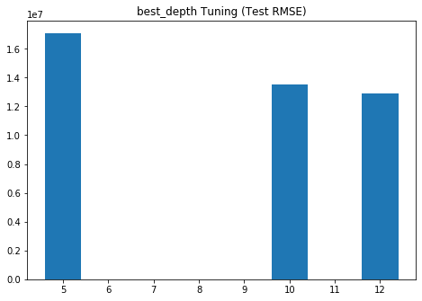

```python
minSplit = 2
best_depth = 5
test_predict1, train_predict1 = DecisionTreeRegressionMethod(best_depth , minSplit , X_train , Y_train , X_test , Y_test)
result1 = evaluateModel(Y_test , test_predict1 , Y_train , train_predict1)

best_depth = 10
test_predict2, train_predict2 = DecisionTreeRegressionMethod(best_depth , minSplit , X_train , Y_train , X_test , Y_test)
result2 = evaluateModel(Y_test , test_predict2 , Y_train , train_predict2)

best_depth = 12
test_predict3, train_predict3 = DecisionTreeRegressionMethod(best_depth , minSplit , X_train , Y_train , X_test , Y_test)
result3 = evaluateModel(Y_test , test_predict3 , Y_train , train_predict3)


fig = plt.figure()
ax = fig.add_axes([0,0,1,1])
ax.set_title("best_depth Tuning (Test RMSE)")
values = [5 , 10 , 12]
results = [result1.loc["RMSE" , "Test"] , result2.loc["RMSE" , "Test"] , result3.loc["RMSE" , "Test"]]
ax.bar(values , results)
plt.show()
```

As shown above by increasing depth the RMSE will drop and that was expected.

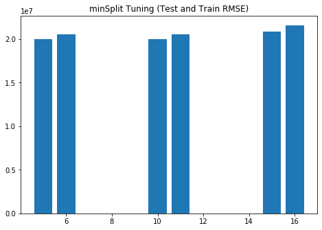

```python
best_depth = 3
minSplit = 5
test_predict1, train_predict1 = DecisionTreeRegressionMethod(best_depth , minSplit , X_train , Y_train , X_test , Y_test)
result1 = evaluateModel(Y_test , test_predict1 , Y_train , train_predict1)

minSplit = 250
test_predict2, train_predict2 = DecisionTreeRegressionMethod(best_depth , minSplit , X_train , Y_train , X_test , Y_test)
result2 = evaluateModel(Y_test , test_predict2 , Y_train , train_predict2)

minSplit = 2000
test_predict3, train_predict3 = DecisionTreeRegressionMethod(best_depth , minSplit , X_train , Y_train , X_test , Y_test)
result3 = evaluateModel(Y_test , test_predict3 , Y_train , train_predict3)


fig = plt.figure()
ax = fig.add_axes([0,0,1,1])
ax.set_title("minSplit Tuning (Test and Train RMSE)")
values = [5  , 6  , 10 , 11 , 15 , 16]
results = [result1.loc["RMSE" , "Test"] , result1.loc["RMSE" , "Train"] ,
           result2.loc["RMSE" , "Test"] , result2.loc["RMSE" , "Train"] ,
           result3.loc["RMSE" , "Test"] , result3.loc["RMSE" , "Train"]]
ax.bar(values , results)
plt.show()
```

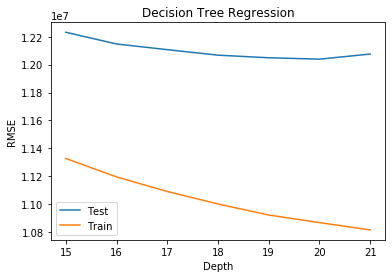

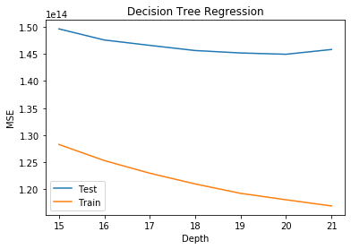

```
Best possible depth: 20
Best possible RMSE: 12039491.917680731
```

```python
def DecisionTreeRegressionTuning(X_train , Y_train , X_test , Y_test):
    trainRMSE = []; testRMSE = [];  trainMSE = []; testMSE = []
    bestIndex = 0
    minRMSE = float("inf")
    for i in list(range(15 , 22)):
        DT = tree.DecisionTreeRegressor(max_depth = i , min_samples_split = 200)
        DT = DT.fit(X_train, Y_train)

        test_predict = DT.predict(X_test)
        train_predict = DT.predict(X_train)

        testRMSE.append(np.sqrt(metrics.mean_squared_error(Y_test , test_predict)))
        testMSE.append(metrics.mean_squared_error(Y_test , test_predict))

        if(np.sqrt(metrics.mean_squared_error(Y_test , test_predict)) < minRMSE):
            minRMSE = np.sqrt(metrics.mean_squared_error(Y_test , test_predict))
            bestIndex = i

        trainRMSE.append(np.sqrt(metrics.mean_squared_error(Y_train , train_predict)))
        trainMSE.append(metrics.mean_squared_error(Y_train , train_predict))

    plt.plot(list(range(15, 22)), testRMSE, label='Test')
    plt.plot(list(range(15, 22)), trainRMSE, label='Train')
    plt.ylabel('RMSE')
    plt.xlabel('Depth')
    plt.title('Decision Tree Regression')
    plt.legend()
    plt.show()

    plt.plot(list(range(15, 22)), testMSE, label='Test')
    plt.plot(list(range(15, 22)), trainMSE, label='Train')
    plt.ylabel('MSE')
    plt.xlabel('Depth')
    plt.title('Decision Tree Regression')
    plt.legend()
    plt.show()

    print("Best possible depth: " + str(bestIndex))
    print("Best possible RMSE: " + str(minRMSE))


DecisionTreeRegressionTuning(X_train , Y_train , X_test , Y_test)
```

The charts above clearly shows a case of overfitting since train results are much better than test results. Also 20 is the best depth in range of 15 to 22 so I chose that one. Higher value for depth isn't always better since you can see on the charts that after 20 the RMSE is rising so we have to find the perfect value by checking multiple depths.

### KNN

n_neighbors is the number of neighbors to use by default for kneighbors queries meaning that it'll check n_neighbors neighbors to assign a label.

```python
def KneighborsRegressionMethod(bestNumofNeighbor , X_train , Y_train , X_test , Y_test):
    KNN = KNeighborsRegressor(n_neighbors = bestNumofNeighbor)
    KNN = KNN.fit(X_train, Y_train)
    test_predict = KNN.predict(X_test)
    train_predict = KNN.predict(X_train)

    return test_predict, train_predict

bestNumofNeighbor = 10
test_predict, train_predict = KneighborsRegressionMethod(bestNumofNeighbor , X_train[0:5000 , :] , Y_train[0:5000] ,
                                                                             X_test[0:5000 , :] , Y_test[0:5000])
result = evaluateModel(Y_test[0:5000] , test_predict , Y_train[0:5000] , train_predict)
result
```

[output not shown]

```python
print("RMSE KNN: " + str(result.loc["RMSE" , "Test"]))
```

```
RMSE KNN: 19542931.882761016
```

#### Important note about KNN

The value printed above (19 million) was one of the best result I got using all the dataset but fewer word features with KNN. I assigned multiple values to max_features in tfidfVectorizer (50 , 100 , 150 , 200 , 250 etc...) but since I got better results in other models by using higher number of features I decided to keep the features but make the dataset of KNN much smaller compared to its original 88000 the reason being it takes forever to get the results with the whole dataset in KNN.

[figure not shown]

```python
bestNumofNeighbor = 5
test_predict1, train_predict1 = KneighborsRegressionMethod(bestNumofNeighbor , X_train[0:100 , :] , Y_train[0:100] ,
                                                                               X_test[0:100 , :] , Y_test[0:100])
result1 = evaluateModel(Y_test[0:100] , test_predict1 , Y_train[0:100] , train_predict1)

bestNumofNeighbor = 15
test_predict2, train_predict2 = KneighborsRegressionMethod(bestNumofNeighbor , X_train[0:100 , :] , Y_train[0:100] ,
                                                                               X_test[0:100 , :] , Y_test[0:100])
result2 = evaluateModel(Y_test[0:100] , test_predict2 , Y_train[0:100] , train_predict2)

bestNumofNeighbor = 100
test_predict3, train_predict3 = KneighborsRegressionMethod(bestNumofNeighbor , X_train[0:100 , :] , Y_train[0:100] ,
                                                                               X_test[0:100 , :] , Y_test[0:100])
result3 = evaluateModel(Y_test[0:100] , test_predict3 , Y_train[0:100] , train_predict3)


fig = plt.figure()
ax = fig.add_axes([0,0,1,1])
ax.set_title("best_depth Tuning (Test RMSE)")
values = [5 , 10 , 15]
results = [result1.loc["RMSE" , "Test"] , result2.loc["RMSE" , "Test"] , result3.loc["RMSE" , "Test"]]
ax.bar(values , results)
plt.show()
```

#### Hyperparameters of Random forest

max_depth is the maximum depth of the tree if the value is too high it can take a really long time to get the results and the model will be really complex also other issues like overfitting can happen.

n_estimators is the number of trees in the forest and get results from all of them and finally determine the result based on them. Raising this value will result in larger number of trees so we can create a more robust aggregate model with less variance at the cost of a greater training time.

max_features is the number of features to consider when looking for the best split meaning that it'll choose a portion of the features based on the set value. This was the game changer and decreased RMSE the most. A small value which means less features considered when splitting at each node will reduce the variance at the cost of higher individual tree bias. High value will obviously have inversed results.

For max_features 0.33 is a good starting point and by trying different values I got the best results with 0.4. sqrt and log2 didn't have any good results at all. For n_estimators I started from 50 and tested values upto 100 meaning I checked 50, 60, 70, 80, 90 and 100 around 70 I got the best results but after checking different values around 70 I came to the understanding that 70 was the best possible choice. For max_depth I used the chart below. So basically every parameter was assigned by trial and error checking RMSE for each of them and finally choosing the best one in the range.

### Random Forest

```python
def RandomForestRegressionMethod(best_depth , X_train , Y_train , X_test , Y_test):
    reg = RandomForestRegressor(max_depth = best_depth , n_estimators = 70 , max_features = 0.4)
    reg = reg.fit(X_train, Y_train)
    test_predict = reg.predict(X_test)
    train_predict = reg.predict(X_train)

    return test_predict, train_predict, reg

best_depth = 20
test_predict, train_predict, reg = RandomForestRegressionMethod(best_depth , X_train , Y_train , X_test , Y_test)
result = evaluateModel(Y_test , test_predict , Y_train , train_predict)
result
```

|  | Test | Train |
| --- | --- | --- |
| MSE | 9.80344e+13 | 3.96877e+13 |
| RMSE | 9.90123e+06 | 6.29981e+06 |

```python
print("RMSE Random Forest: " + str(result.loc["RMSE" , "Test"]))
```

```
RMSE Random Forest: 9901232.679196453
```

## 10 Million RMSE Goal Reached in Random Forest!

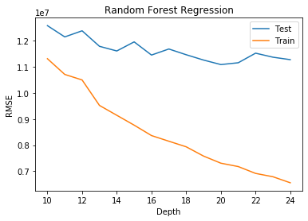

```
Best possible depth: 20
Best possible RMSE: 11085852.613239648
```

```python
def RandomForestRegressionTuning(X_train , Y_train , X_test , Y_test):

    trainRMSE = []; testRMSE = []
    bestIndex = 0
    minRMSE = float("inf")
    for i in list(range(10,25)):
        randomForest = RandomForestRegressor(max_depth = i , n_estimators = 10 , max_features = 0.4)
        randomForest = randomForest.fit(X_train, Y_train)

        test_predict = randomForest.predict(X_test)
        train_predict = randomForest.predict(X_train)

        testRMSE.append(np.sqrt(metrics.mean_squared_error(Y_test , test_predict)))

        if(np.sqrt(metrics.mean_squared_error(Y_test , test_predict)) < minRMSE):
            minRMSE = np.sqrt(metrics.mean_squared_error(Y_test , test_predict))
            bestIndex = i

        trainRMSE.append(np.sqrt(metrics.mean_squared_error(Y_train , train_predict)))

    plt.plot(list(range(10, 25)), testRMSE, label = 'Test')
    plt.plot(list(range(10, 25)), trainRMSE, label = 'Train')
    plt.ylabel('RMSE')
    plt.xlabel('Depth')
    plt.title('Random Forest Regression')
    plt.legend()
    plt.show()
    print("Best possible depth: " + str(bestIndex))
    print("Best possible RMSE: " + str(minRMSE))

RandomForestRegressionTuning(X_train , Y_train , X_test , Y_test)
```

#### Some info + Question 7

As the results show above we can see that random forest performs much better than decision tree and we were expecting such behaviour since random forest gets info from multiple trees and finally generates the result in comparision to decision tree which is only one tree.

Bias: Difference between the average prediction of our model and the correct value which we are trying to predict. Model with high bias pays very little attention to the training data and oversimplifies the model. It always leads to high error on training and test data. So when bias is high it'll mean that our model is simple so it'll result in underfitting

Variance: Variability of model prediction for a given data point or a value which tells us spread of our data. Model with high variance pays a lot of attention to training data and does not generalize on the data which it hasn’t seen before. As a result, such models perform very well on training data but has high error rates on test data. So when variance is high it'll mean that model is too complex and also performs better on train set rather than test set so it'll result in overfitting

From bias point of view since random forest gets info from several trees there's small chance of underfitting so it'll be better and perform better. Form variance point of view decision trees are prone to overfitting especially when a tree is particularly deep but random forest rarely overfits so in this case is better too so it'll perform better. All in all since random forest gets information from multiple trees and basically consults and take a look at each of the trees' results before making a decision it'll have better results. One way Random Forests reduce variance is by training on different samples of the data. A second way is by using a random subset of features that we used here in the project as well. In random forest if we use many trees in our forest, eventually many or all of our features will have been included. This inclusion of many features will help limit our error due to bias and error due to variance. The achieved results clearly show that random forest performs better.

### References

All the links provided in the project description.